# hs_post_clean

Autogenerated data summary from dataMaid

2023-10-06 11:42:36.539527

# Data report overview

The dataset examined has the following dimensions:

| Feature | Result |
| --- | --- |
| Number of observations | 2603 |
| Number of variables | 74 |

### Checks performed

The following variable checks were performed, depending on the data type of each variable:

|  | character | factor | labelled | haven labelled | numeric | integer | logical | Date |
| --- | --- | --- | --- | --- | --- | --- | --- | --- |
| Identify miscoded missing values | × | × | × | × | × | × |  | × |
| Identify prefixed and suffixed whitespace | × | × | × | × |  |  |  |  |
| Identify levels with < 6 obs. | × | × | × | × |  |  |  |  |
| Identify case issues | × | × | × | × |  |  |  |  |
| Identify misclassified numeric or integer variables | × | × | × | × |  |  |  |  |
| Identify outliers |  |  |  |  | × | × |  | × |

Please note that all numerical values in the following have been rounded to 2 decimals.

# Summary table

|  | Variable class | # unique values | Missing observations | Any problems? |
| --- | --- | --- | --- | --- |
| X | integer | 2603 | 0.00 % |  |
| renewvia_id | character | 2316 | 0.00 % | × |
| interviewed_before | character | 4 | 0.00 % | × |
| connection_period | character | 7 | 0.00 % | × |
| country | character | 3 | 0.00 % | × |
| age | character | 76 | 0.00 % | × |
| gender | character | 3 | 0.00 % | × |
| occupation_change | character | 3 | 0.00 % | × |
| household_income_change | character | 4 | 0.00 % | × |
| avg_household_income | integer | 136 | 19.59 % | × |
| household_headcount_change | character | 5 | 0.00 % | × |
| girls_schooling_change | character | 4 | 0.00 % | × |
| boys_schooling_change | character | 4 | 0.00 % | × |
| school_performance_change | character | 4 | 0.00 % | × |
| girls_unschooled_reasons | character | 9 | 0.00 % | × |
| boys_unschooled_reasons | character | 9 | 0.00 % | × |
| household_business_owners | character | 7 | 0.00 % | × |
| business_type | character | 353 | 0.00 % | × |
| business_recent | character | 3 | 0.00 % | × |
| business_from_minigrid | character | 4 | 0.00 % | × |
| business_use_minigrid | character | 3 | 0.00 % | × |
| power_sources | character | 92 | 0.00 % | × |
| power_sources_usage | character | 5 | 0.00 % | × |
| power_sources_primary | character | 11 | 0.00 % | × |
| appliances_count | integer | 23 | 18.33 % | × |
| appliances_count_change | character | 3 | 0.00 % | × |
| cellphones_count | integer | 14 | 18.02 % | × |
| appliances_type | character | 219 | 0.00 % | × |
| appliances_type_addition | character | 195 | 0.00 % | × |
| light_hours_current | integer | 23 | 17.94 % | × |
| light_primary_sources | character | 27 | 0.00 % | × |
| kerosene_lamp_usage_change | character | 4 | 0.00 % | × |
| kerosene_lamps_count | integer | 14 | 25.16 % |  |
| kerosene_lamp_usage_time | character | 7 | 0.00 % | × |
| kerosene_lamps_cost | character | 7 | 0.00 % | × |
| cooking_energy_sources | character | 7 | 0.00 % | × |
| cooking_fuel_collection_time | character | 6 | 0.00 % | × |
| cooking_fuel_responsible | character | 46 | 0.00 % | × |
| cooking_energy_cost | character | 8 | 0.00 % | × |
| applicances_charging_sources | character | 7 | 0.00 % | × |
| applicances_charging_cost | character | 8 | 0.00 % | × |
| community_lights | character | 3 | 0.00 % | × |
| home_exterior_lights | character | 3 | 0.00 % | × |
| exterior_lights_minigrid | character | 3 | 0.00 % | × |
| feel_safe_dark | character | 6 | 0.00 % | × |
| feel_safe_if_exterior_lights | character | 6 | 0.00 % | × |
| feel_unsafe_reasons | character | 6 | 0.00 % | × |
| feel_safer_with_minigrid | character | 1284 | 0.00 % | × |
| phone_charge_location | character | 5 | 0.00 % | × |
| phone_charge_frequency | character | 5 | 0.00 % | × |
| phone_charge_cost | character | 8 | 0.00 % | × |
| phone_charge_travel_distance | character | 9 | 0.00 % | × |
| water_source | character | 6 | 0.00 % | × |
| clean_drinking_water | character | 3 | 0.00 % | × |
| clean_drinking_water_source | character | 5 | 0.00 % | × |
| community_clean_water_source | character | 106 | 0.00 % | × |
| water_collection_travel_distance | character | 7 | 0.00 % | × |
| water_collection_time | character | 6 | 0.00 % | × |
| water_collection_responsible | character | 6 | 0.00 % | × |
| avg_person_age_water_collection | character | 7 | 0.00 % | × |
| water_cost | character | 7 | 0.00 % | × |
| clinic_travel_distance | character | 7 | 0.00 % | × |
| clinic_electricity_access_minigrid | character | 3 | 0.00 % | × |
| clinic_refrigeration_access | character | 3 | 0.00 % | × |
| better_access_health_minigrid | character | 3 | 0.00 % | × |
| minigrid_access_life_improvement | character | 3 | 0.00 % | × |
| minigrid_access_productivity_improvement | character | 1440 | 0.00 % | × |
| minigrid_effect_on_household_female | character | 1157 | 0.00 % | × |
| end_date | character | 60 | 0.00 % | × |
| customerAccountNumber | integer | 966 | 56.97 % | × |
| tariff | character | 4 | 0.00 % | × |
| business_owners_count | integer | 3 | 0.00 % |  |
| business_owners_female | integer | 2 | 0.00 % |  |
| appliances_addition_count | integer | 7 | 0.00 % | × |

# Variable list

## X

| Feature | Result |
| --- | --- |
| Variable type | integer |
| Number of missing obs. | 0 (0 %) |
| Number of unique values | 2603 |
| Median | 1301 |
| 1st and 3rd quartiles | 650.5; 1951.5 |
| Min. and max. | 0; 2602 |

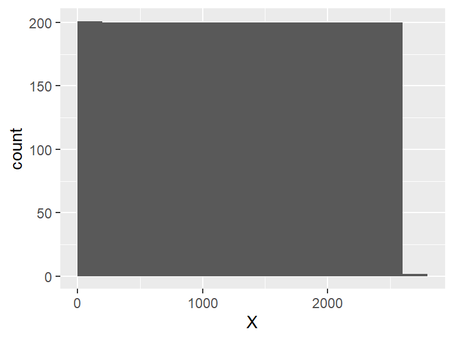

## renewvia_id

| Feature | Result |
| --- | --- |
| Variable type | character |
| Number of missing obs. | 0 (0 %) |
| Number of unique values | 2316 |
| Mode | “161083” |

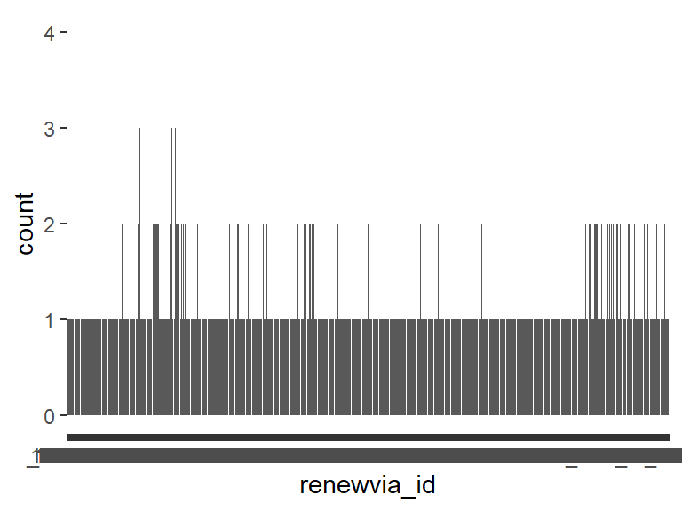

- The following suspected missing value codes enter as regular values: "".
- Note that the following levels have at most five observations: "", "_161147", "_nd0043", "1050", "131104", …, "rn2836", "rn2838", "rn2839", "rn3646", "see_141201" (2306 values omitted).

## interviewed_before

| Feature | Result |
| --- | --- |
| Variable type | character |
| Number of missing obs. | 0 (0 %) |
| Number of unique values | 4 |
| Mode | “yes” |

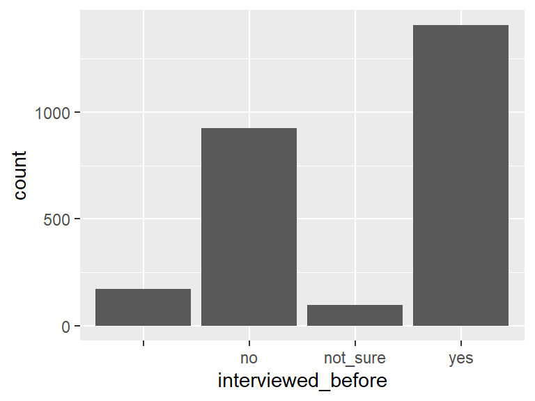

- The following suspected missing value codes enter as regular values: "".

## connection_period

| Feature | Result |
| --- | --- |
| Variable type | character |
| Number of missing obs. | 0 (0 %) |
| Number of unique values | 7 |
| Mode | “12_24_months” |

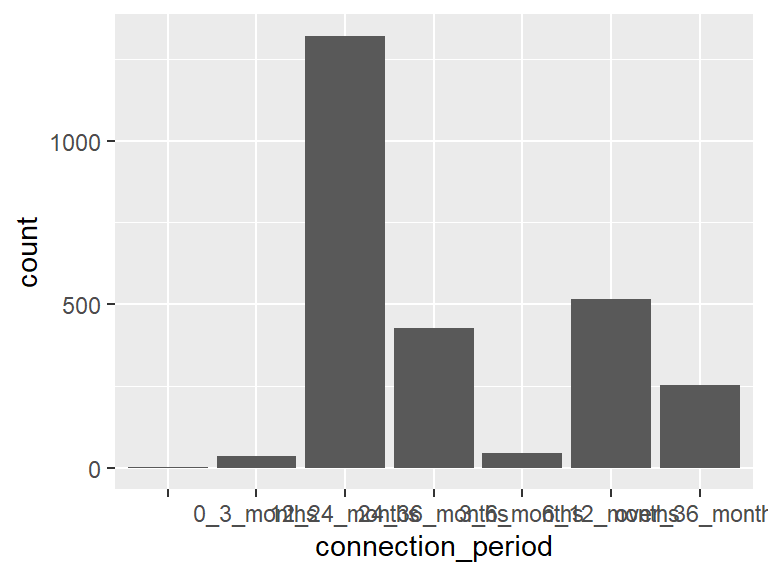

- The following suspected missing value codes enter as regular values: "".
- Note that the following levels have at most five observations: "".

## country

| Feature | Result |
| --- | --- |
| Variable type | character |
| Number of missing obs. | 0 (0 %) |
| Number of unique values | 3 |
| Mode | “kenya” |

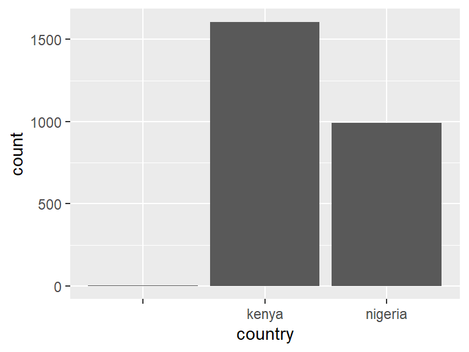

- The following suspected missing value codes enter as regular values: "".
- Note that the following levels have at most five observations: "".

## age

| Feature | Result |
| --- | --- |
| Variable type | character |
| Number of missing obs. | 0 (0 %) |
| Number of unique values | 76 |
| Mode | “” |

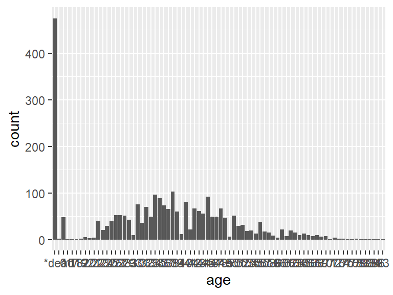

- The following suspected missing value codes enter as regular values: "".
- Note that the following levels have at most five observations: "*dead", "10", "17", "18", "19", …, "80", "83", "84", "86", "93" (12 values omitted).

## gender

| Feature | Result |
| --- | --- |
| Variable type | character |
| Number of missing obs. | 0 (0 %) |
| Number of unique values | 3 |
| Mode | “male” |

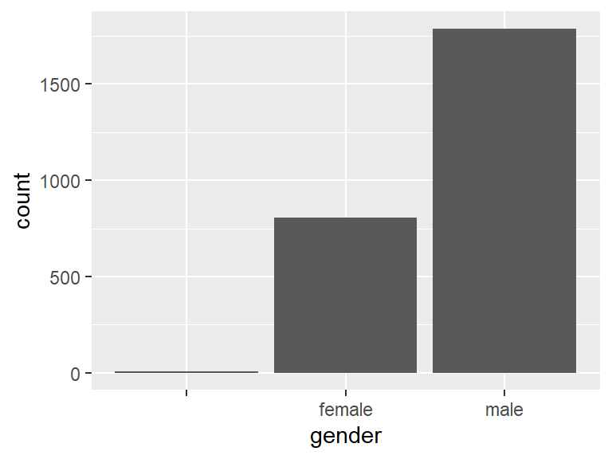

- The following suspected missing value codes enter as regular values: "".

## occupation_change

| Feature | Result |
| --- | --- |
| Variable type | character |
| Number of missing obs. | 0 (0 %) |
| Number of unique values | 3 |
| Mode | “no” |

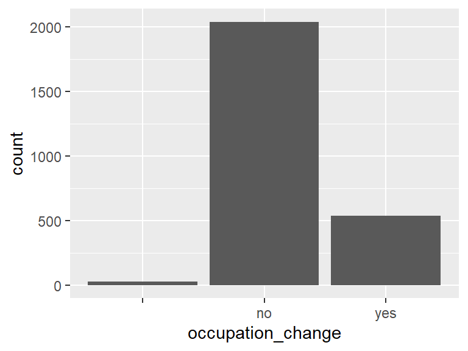

- The following suspected missing value codes enter as regular values: "".

## household_income_change

| Feature | Result |
| --- | --- |
| Variable type | character |
| Number of missing obs. | 0 (0 %) |
| Number of unique values | 4 |
| Mode | “no_it_is_the_same” |

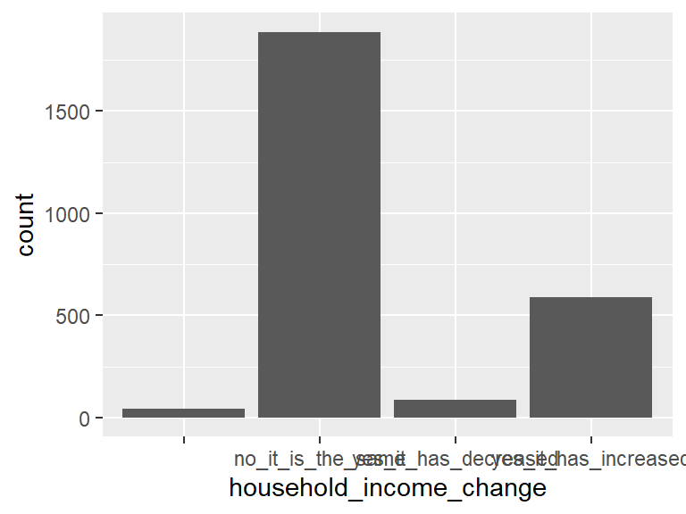

- The following suspected missing value codes enter as regular values: "".

## avg_household_income

| Feature | Result |
| --- | --- |
| Variable type | integer |
| Number of missing obs. | 510 (19.59 %) |
| Number of unique values | 135 |
| Median | 10000 |
| 1st and 3rd quartiles | 1500; 20000 |
| Min. and max. | 0; 300000 |

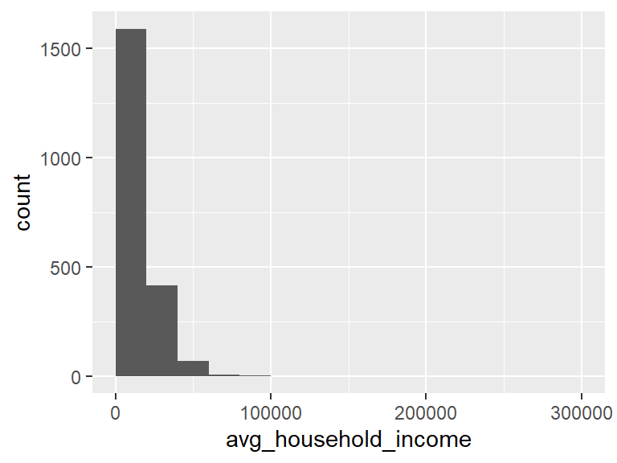

- Note that the following possible outlier values were detected: "100000", "140000", "150000", "200000", "300000".

## household_headcount_change

| Feature | Result |
| --- | --- |
| Variable type | character |
| Number of missing obs. | 0 (0 %) |
| Number of unique values | 5 |
| Mode | “no” |

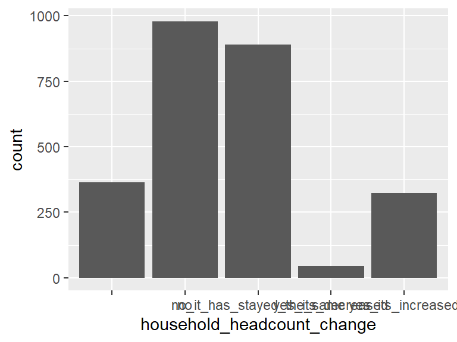

- The following suspected missing value codes enter as regular values: "".

## girls_schooling_change

| Feature | Result |
| --- | --- |
| Variable type | character |
| Number of missing obs. | 0 (0 %) |
| Number of unique values | 4 |
| Mode | “no_its_the_same” |

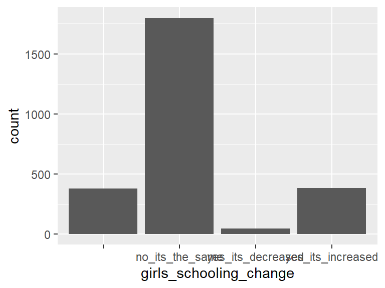

- The following suspected missing value codes enter as regular values: "".

## boys_schooling_change

| Feature | Result |
| --- | --- |
| Variable type | character |
| Number of missing obs. | 0 (0 %) |
| Number of unique values | 4 |
| Mode | “no_its_the_same” |

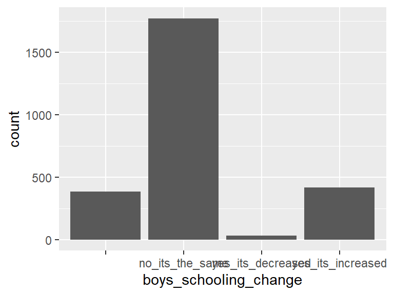

- The following suspected missing value codes enter as regular values: "".

## school_performance_change

| Feature | Result |
| --- | --- |
| Variable type | character |
| Number of missing obs. | 0 (0 %) |
| Number of unique values | 4 |
| Mode | “no_its_the_same” |

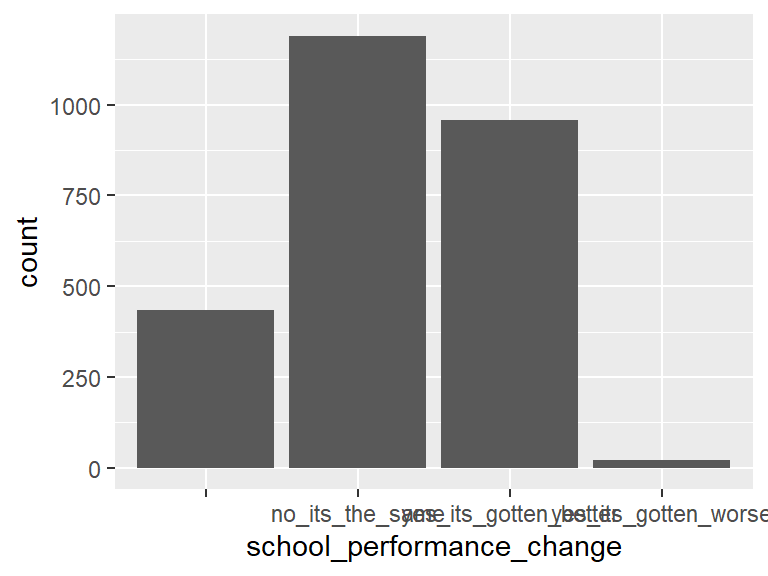

- The following suspected missing value codes enter as regular values: "".

## girls_unschooled_reasons

| Feature | Result |
| --- | --- |
| Variable type | character |
| Number of missing obs. | 0 (0 %) |
| Number of unique values | 9 |
| Mode | “they_all_attend_school” |

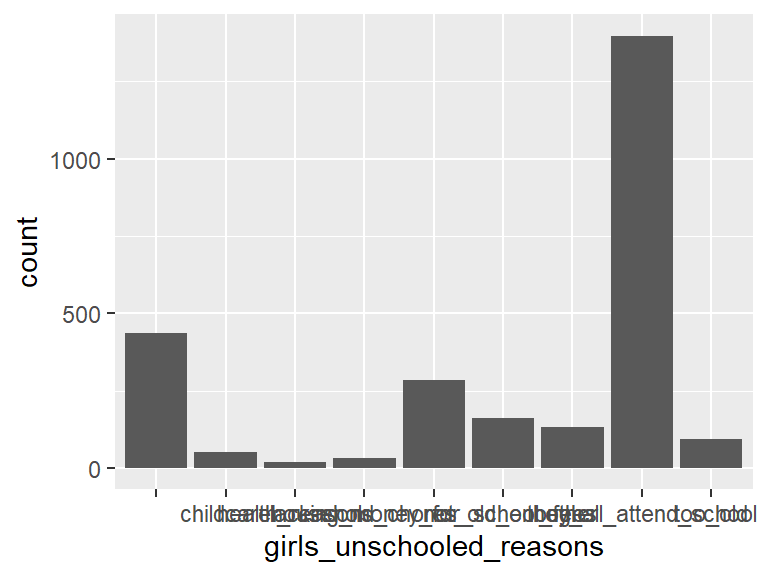

- The following suspected missing value codes enter as regular values: "".

## boys_unschooled_reasons

| Feature | Result |
| --- | --- |
| Variable type | character |
| Number of missing obs. | 0 (0 %) |
| Number of unique values | 9 |
| Mode | “they_all_attend_school” |

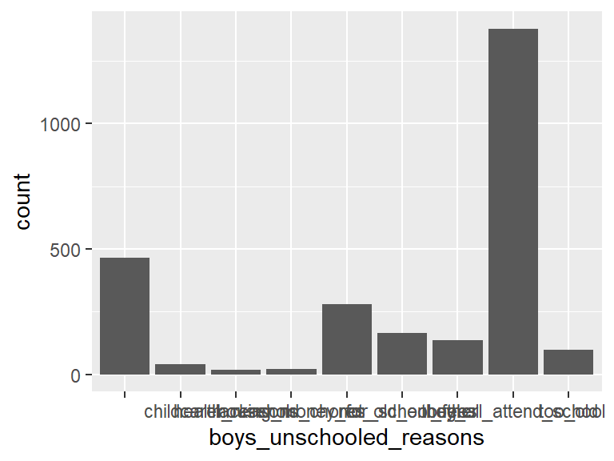

- The following suspected missing value codes enter as regular values: "".

## household_business_owners

| Feature | Result |
| --- | --- |
| Variable type | character |
| Number of missing obs. | 0 (0 %) |
| Number of unique values | 7 |
| Mode | “” |

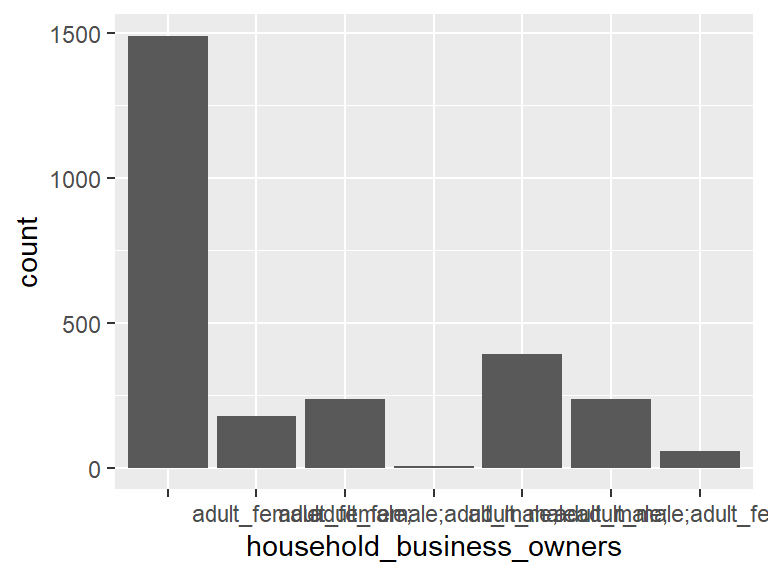

- The following suspected missing value codes enter as regular values: "".

## business_type

| Feature | Result |
| --- | --- |
| Variable type | character |
| Number of missing obs. | 0 (0 %) |
| Number of unique values | 353 |
| Mode | “” |

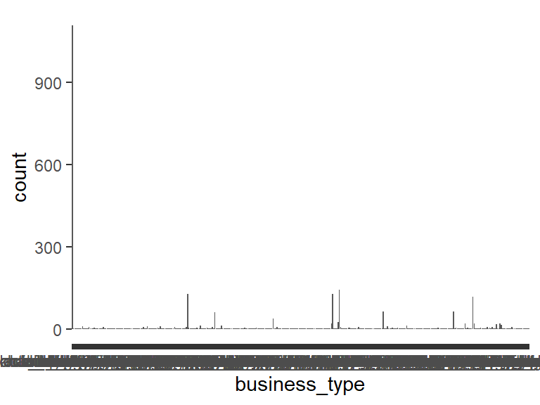

- The following suspected missing value codes enter as regular values: "".
- Note that the following levels have at most five observations: "_none", "0", "animal_business", "auto_mechanic", "auto_mechanic_and_spare_parts_shop", …, "wine_bar", "wines_and_spirits_sales", "winners_pastor", "workman", "yes" (308 values omitted).

## business_recent

| Feature | Result |
| --- | --- |
| Variable type | character |
| Number of missing obs. | 0 (0 %) |
| Number of unique values | 3 |
| Mode | “no” |

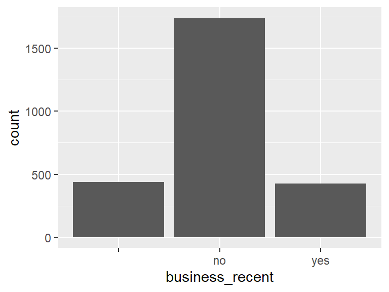

- The following suspected missing value codes enter as regular values: "".

## business_from_minigrid

| Feature | Result |
| --- | --- |
| Variable type | character |
| Number of missing obs. | 0 (0 %) |
| Number of unique values | 4 |
| Mode | “no” |

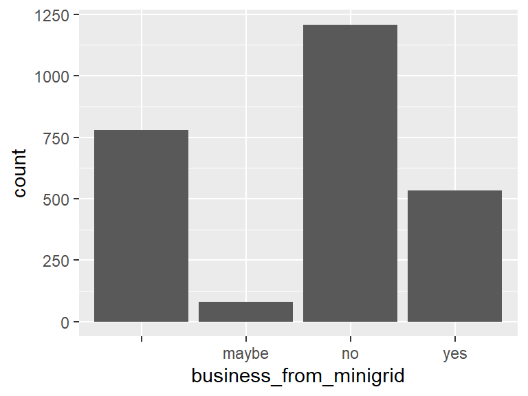

- The following suspected missing value codes enter as regular values: "".

## business_use_minigrid

| Feature | Result |
| --- | --- |
| Variable type | character |
| Number of missing obs. | 0 (0 %) |
| Number of unique values | 3 |
| Mode | “no” |

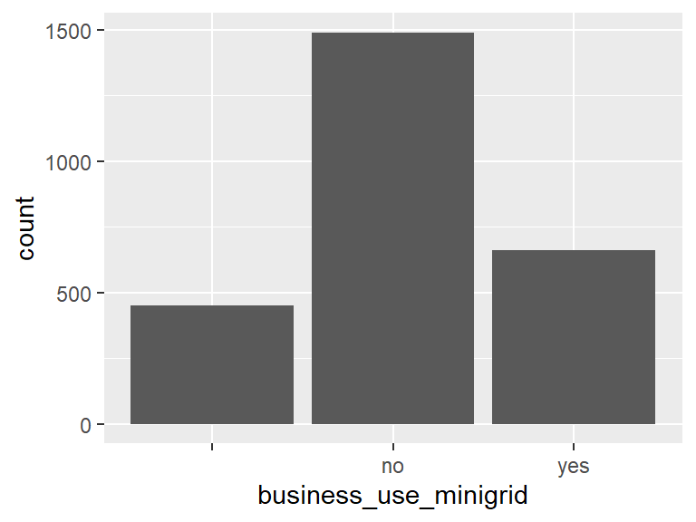

- The following suspected missing value codes enter as regular values: "".

## power_sources

| Feature | Result |
| --- | --- |
| Variable type | character |
| Number of missing obs. | 0 (0 %) |
| Number of unique values | 92 |
| Mode | “minigrid_electricity_renewvia;” |

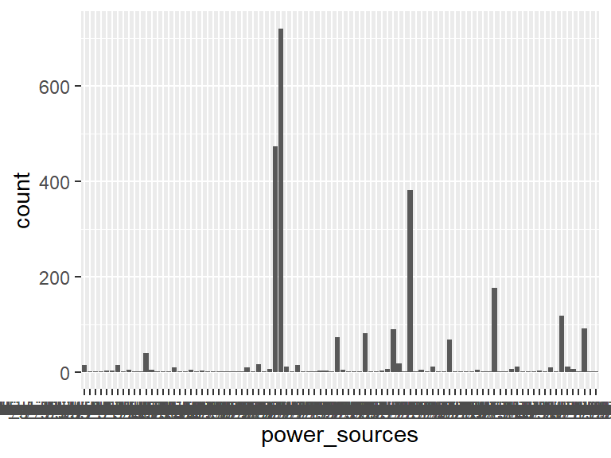

- The following suspected missing value codes enter as regular values: "".
- Note that the following levels have at most five observations: "candles;", "candles;charcoal;minigrid_electricity_renewvia;", "candles;diesel_generator;solar_home_kit;", "candles;minigrid_electricity_renewvia;", "candles_minigrid_electricity_renewvia", …, "solar_home_kit_kerosene_lamp_candles_minigrid_electricity_renewvia", "solar_home_kit_kerosene_lamp_petrol_generator_minigrid_electricity_renewvia", "solar_home_kit_petrol_generator_candles_minigrid_electricity_renewvia", "solar_home_kit_petrol_generator_minigrid_electricity_renewvia_other", "solar_panel;" (55 values omitted).

## power_sources_usage

| Feature | Result |
| --- | --- |
| Variable type | character |
| Number of missing obs. | 0 (0 %) |
| Number of unique values | 5 |
| Mode | “more_than_8_hours” |

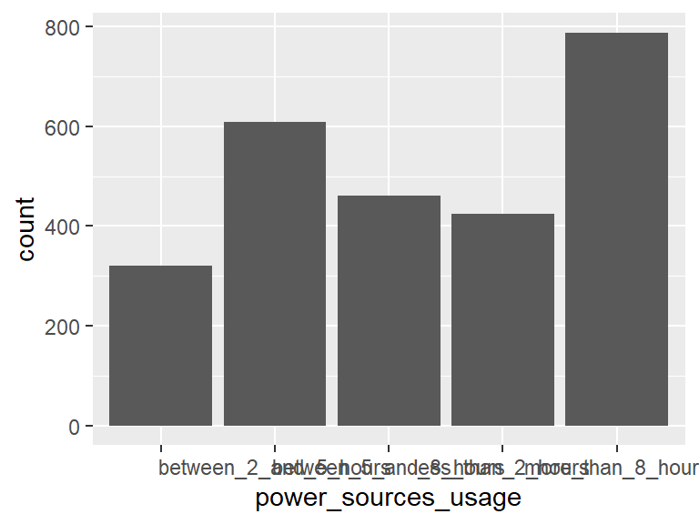

- The following suspected missing value codes enter as regular values: "".

## power_sources_primary

| Feature | Result |
| --- | --- |
| Variable type | character |
| Number of missing obs. | 0 (0 %) |
| Number of unique values | 11 |
| Mode | “minigrid_electricity_renewvia” |

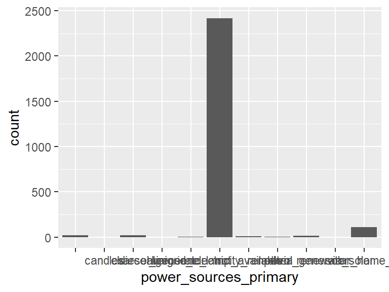

- The following suspected missing value codes enter as regular values: "".
- Note that the following levels have at most five observations: "candles", "diesel_generator", "other", "renewvia_solar".

## appliances_count

| Feature | Result |
| --- | --- |
| Variable type | integer |
| Number of missing obs. | 477 (18.33 %) |
| Number of unique values | 22 |
| Median | 4 |
| 1st and 3rd quartiles | 2; 6 |
| Min. and max. | 0; 53 |

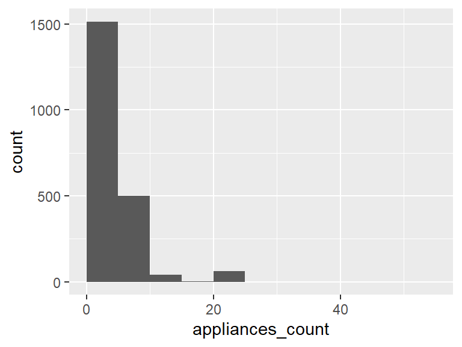

- Note that the following possible outlier values were detected: "13", "14", "15", "17", "18", "24", "25", "30", "53".

## appliances_count_change

| Feature | Result |
| --- | --- |
| Variable type | character |
| Number of missing obs. | 0 (0 %) |
| Number of unique values | 3 |
| Mode | “yes” |

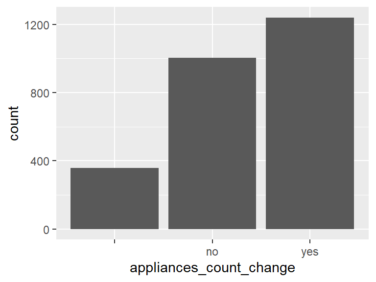

- The following suspected missing value codes enter as regular values: "".

## cellphones_count

| Feature | Result |
| --- | --- |
| Variable type | integer |
| Number of missing obs. | 469 (18.02 %) |
| Number of unique values | 13 |
| Median | 2 |
| 1st and 3rd quartiles | 2; 3 |
| Min. and max. | 0; 39 |

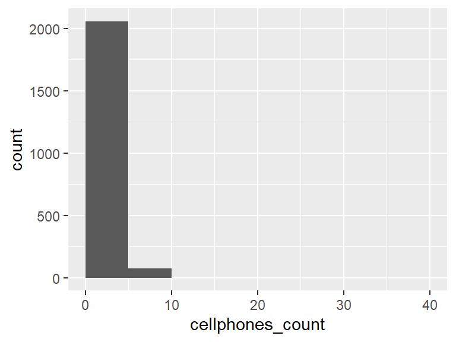

- Note that the following possible outlier values were detected: "0", "1", "25", "39".

## appliances_type

| Feature | Result |
| --- | --- |
| Variable type | character |
| Number of missing obs. | 0 (0 %) |
| Number of unique values | 219 |
| Mode | “radio;lights;cell_phone_charger;” |

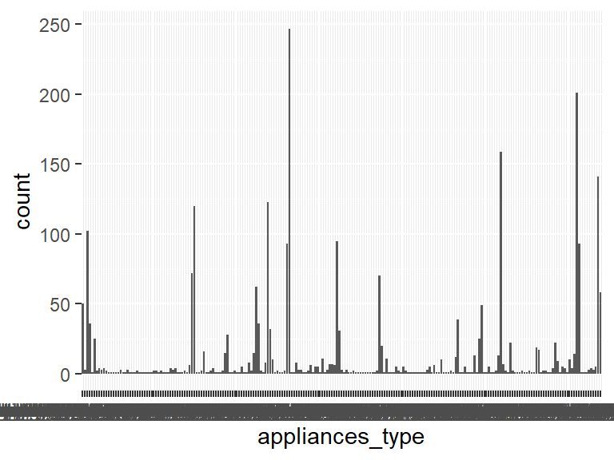

- The following suspected missing value codes enter as regular values: "".
- Note that the following levels have at most five observations: "cell_phone_charger", "cell_phone_charger;lights;computer;", "cell_phone_charger;lights;radio;television;", "cell_phone_charger;lights;television;", "cell_phone_charger;lights;television;radio;", …, "television_radio_fan_cell_phone_charger", "television_radio_fan_cell_phone_charger_other", "television_radio_lights_cell_phone_charger", "television_radio_lights_cell_phone_charger_other", "television_radio_lights_fan" (157 values omitted).

## appliances_type_addition

| Feature | Result |
| --- | --- |
| Variable type | character |
| Number of missing obs. | 0 (0 %) |
| Number of unique values | 195 |
| Mode | “” |

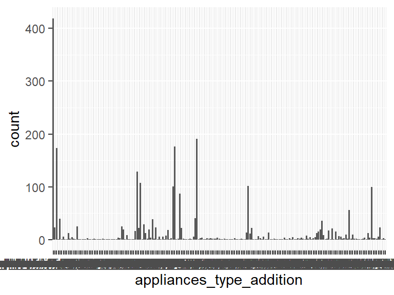

- The following suspected missing value codes enter as regular values: "".
- Note that the following levels have at most five observations: "cell_phone_charger;computer;", "cell_phone_charger;lights;other;", "cell_phone_charger;lights;radio;computer;", "cell_phone_charger;lights;television;", "cell_phone_charger;other;", …, "television;radio;lights;fan", "television;radio;lights;fan;", "television;radio;lights;fan;cell_phone_charger;other", "television;radio;lights;fan;cell_phone_charger;other;", "television;radio;lights;fan;other" (130 values omitted).

## light_hours_current

| Feature | Result |
| --- | --- |
| Variable type | integer |
| Number of missing obs. | 467 (17.94 %) |
| Number of unique values | 22 |
| Median | 6 |
| 1st and 3rd quartiles | 4; 12 |
| Min. and max. | 0; 200 |

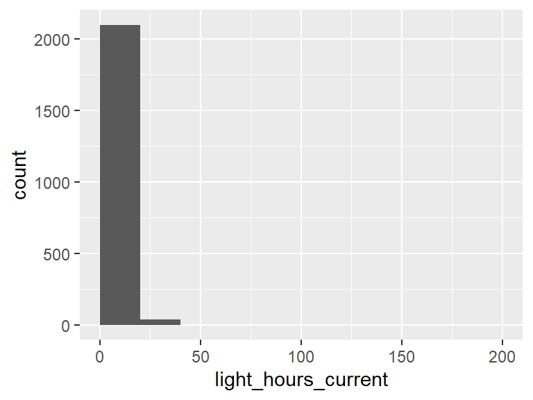

- Note that the following possible outlier values were detected: "0", "200".

## light_primary_sources

| Feature | Result |
| --- | --- |
| Variable type | character |
| Number of missing obs. | 0 (0 %) |
| Number of unique values | 27 |
| Mode | “renewvia_minigrid_electricity;” |

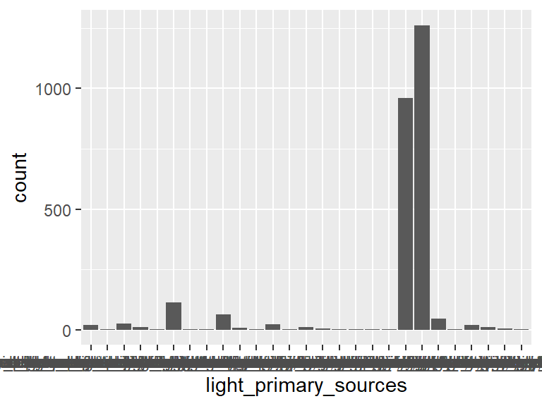

- The following suspected missing value codes enter as regular values: "".
- Note that the following levels have at most five observations: "battery_powered_flashlighttorch", "battery_powered_flashlighttorch;kerosene_source_kerosene_lamps;", "battery_powered_flashlighttorch;renewvia_minigrid_electricity;electric_source_phone_light_electric_lightbulb;", "battery_powered_flashlighttorch;renewvia_minigrid_electricity;kerosene_source_kerosene_lamps;", "electric_source_phone_light_electric_lightbulb;kerosene_source_kerosene_lamps;", …, "kerosene_source_kerosene_lamps;renewvia_minigrid_electricity;", "kerosene_source_kerosene_lamps;renewvia_minigrid_electricity;battery_powered_flashlighttorch;", "kerosene_source_kerosene_lamps;renewvia_minigrid_electricity;electric_source_phone_light_electric_lightbulb;", "renewvia_minigrid_electricity;battery_powered_flashlighttorch;electric_source_phone_light_electric_lightbulb;", "renewvia_minigrid_electricity;kerosene_source_kerosene_lamps;battery_powered_flashlighttorch;" (3 values omitted).

## kerosene_lamp_usage_change

| Feature | Result |
| --- | --- |
| Variable type | character |
| Number of missing obs. | 0 (0 %) |
| Number of unique values | 4 |
| Mode | “yes_its_decreased” |

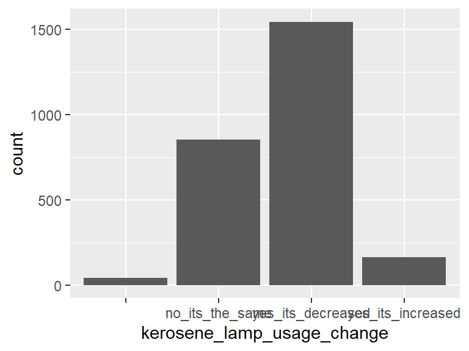

- The following suspected missing value codes enter as regular values: "".

## kerosene_lamps_count

| Feature | Result |
| --- | --- |
| Variable type | integer |
| Number of missing obs. | 655 (25.16 %) |
| Number of unique values | 13 |
| Median | 0 |
| 1st and 3rd quartiles | 0; 1 |
| Min. and max. | 0; 24 |

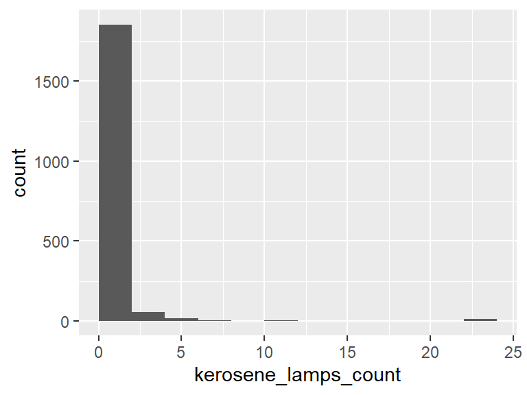

## kerosene_lamp_usage_time

| Feature | Result |
| --- | --- |
| Variable type | character |
| Number of missing obs. | 0 (0 %) |
| Number of unique values | 7 |
| Mode | “we_dont_use_a_kerosene_lamp” |

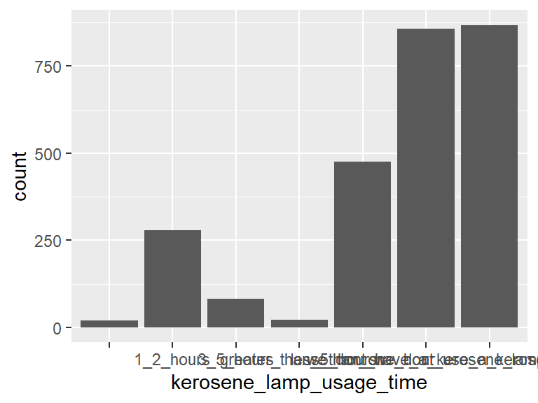

- The following suspected missing value codes enter as regular values: "".

## kerosene_lamps_cost

| Feature | Result |
| --- | --- |
| Variable type | character |
| Number of missing obs. | 0 (0 %) |
| Number of unique values | 7 |
| Mode | “nothing” |

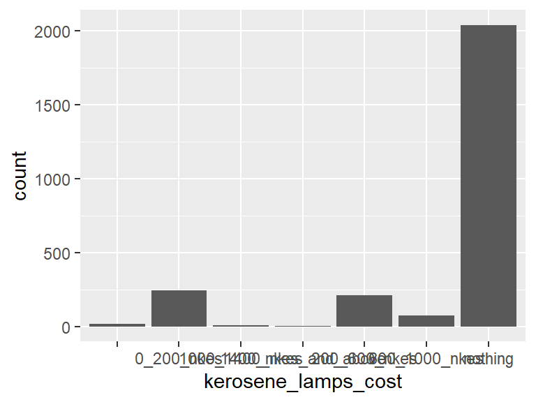

- The following suspected missing value codes enter as regular values: "".
- Note that the following levels have at most five observations: "1400_nkes_and_above".

## cooking_energy_sources

| Feature | Result |
| --- | --- |
| Variable type | character |
| Number of missing obs. | 0 (0 %) |
| Number of unique values | 7 |
| Mode | “firewood” |

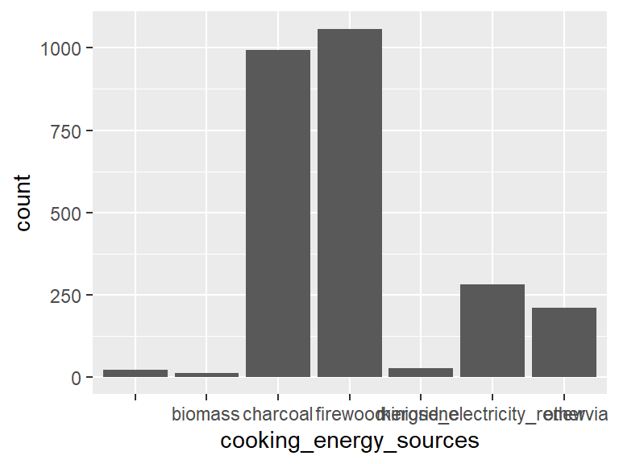

- The following suspected missing value codes enter as regular values: "".

## cooking_fuel_collection_time

| Feature | Result |
| --- | --- |
| Variable type | character |
| Number of missing obs. | 0 (0 %) |
| Number of unique values | 6 |
| Mode | “less_than_1_hour” |

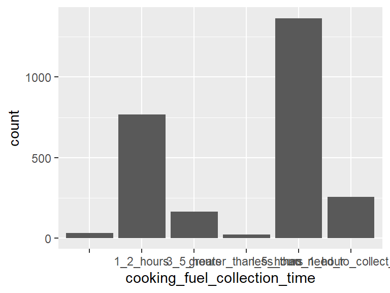

- The following suspected missing value codes enter as regular values: "".

## cooking_fuel_responsible

| Feature | Result |
| --- | --- |
| Variable type | character |
| Number of missing obs. | 0 (0 %) |
| Number of unique values | 46 |
| Mode | “adult_female;” |

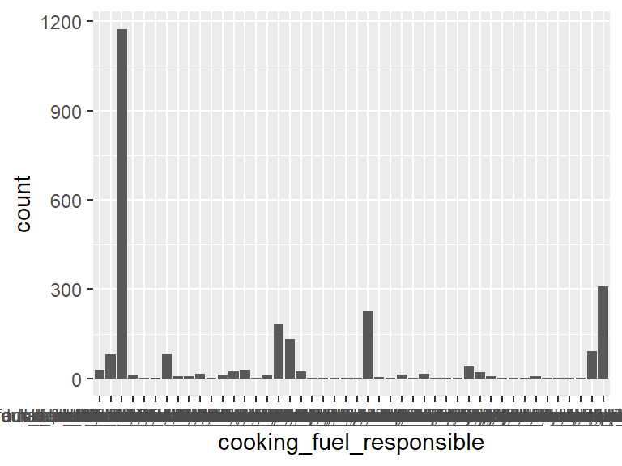

- The following suspected missing value codes enter as regular values: "".
- Note that the following levels have at most five observations: "adult_female;adult_male;child_female;", "adult_female;adult_male;child_female;whole_family;", "adult_female;whole_family;", "adult_female_child_male_whole_family__shared_responsibility", "adult_male;adult_female;child_male;child_female;", …, "child_female;child_male;adult_male;", "child_male;adult_female;child_female;", "child_male;child_female;adult_female;", "child_male_child_female", "child_male_child_female_whole_family__shared_responsibility" (12 values omitted).

## cooking_energy_cost

| Feature | Result |
| --- | --- |
| Variable type | character |
| Number of missing obs. | 0 (0 %) |
| Number of unique values | 8 |
| Mode | “0_1000_nkes” |

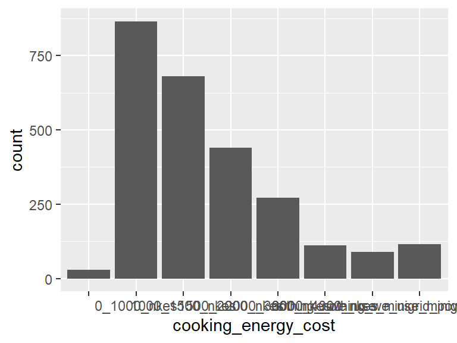

- The following suspected missing value codes enter as regular values: "".

## applicances_charging_sources

| Feature | Result |
| --- | --- |
| Variable type | character |
| Number of missing obs. | 0 (0 %) |
| Number of unique values | 7 |
| Mode | “minigrid_electricity_renewvia” |

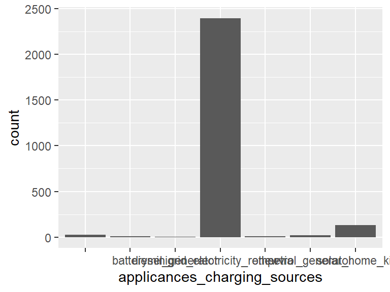

- The following suspected missing value codes enter as regular values: "".
- Note that the following levels have at most five observations: "diesel_generator".

## applicances_charging_cost

| Feature | Result |
| --- | --- |
| Variable type | character |
| Number of missing obs. | 0 (0 %) |
| Number of unique values | 8 |
| Mode | “nothing__we_use_minigrid_power” |

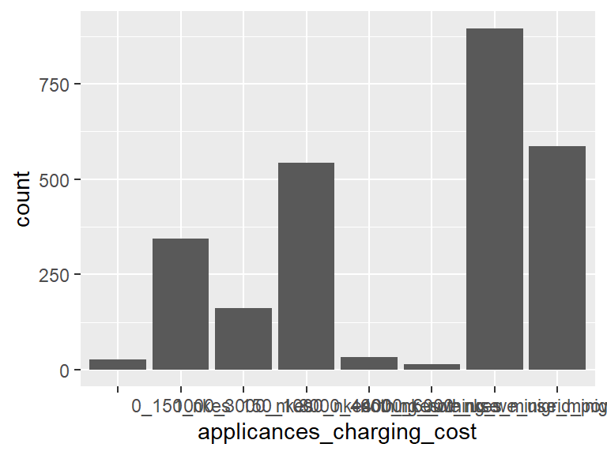

- The following suspected missing value codes enter as regular values: "".

## community_lights

| Feature | Result |
| --- | --- |
| Variable type | character |
| Number of missing obs. | 0 (0 %) |
| Number of unique values | 3 |
| Mode | “yes” |

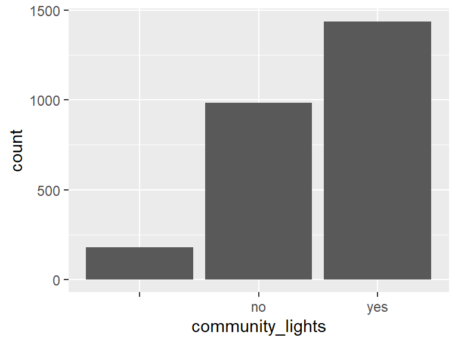

- The following suspected missing value codes enter as regular values: "".

## home_exterior_lights

| Feature | Result |
| --- | --- |
| Variable type | character |
| Number of missing obs. | 0 (0 %) |
| Number of unique values | 3 |
| Mode | “yes” |

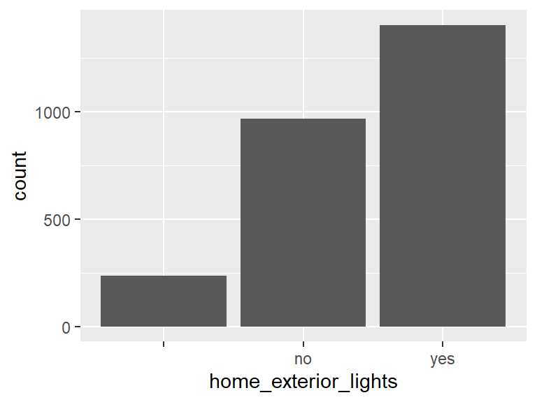

- The following suspected missing value codes enter as regular values: "".

## exterior_lights_minigrid

| Feature | Result |
| --- | --- |
| Variable type | character |
| Number of missing obs. | 0 (0 %) |
| Number of unique values | 3 |
| Mode | “yes” |

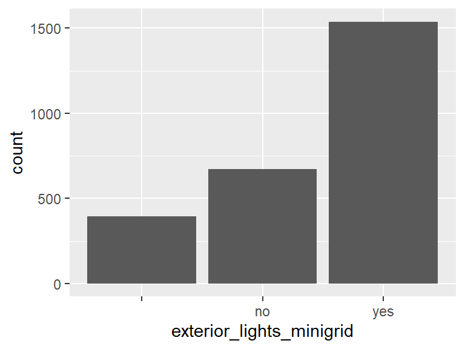

- The following suspected missing value codes enter as regular values: "".

## feel_safe_dark

| Feature | Result |
| --- | --- |
| Variable type | character |
| Number of missing obs. | 0 (0 %) |
| Number of unique values | 6 |
| Mode | “very_unsafe” |

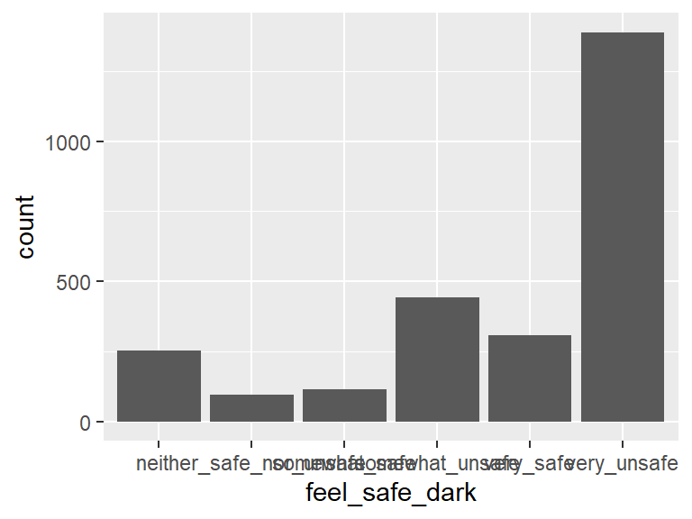

- The following suspected missing value codes enter as regular values: "".

## feel_safe_if_exterior_lights

| Feature | Result |
| --- | --- |
| Variable type | character |
| Number of missing obs. | 0 (0 %) |
| Number of unique values | 6 |
| Mode | “very_safe” |

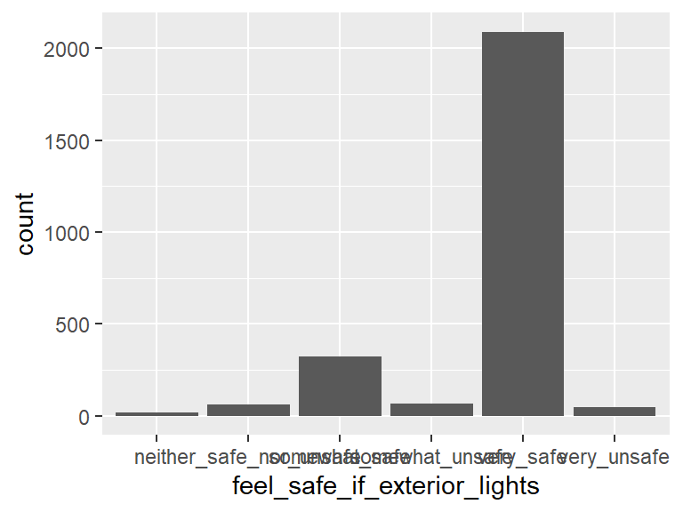

- The following suspected missing value codes enter as regular values: "".

## feel_unsafe_reasons

| Feature | Result |
| --- | --- |
| Variable type | character |
| Number of missing obs. | 0 (0 %) |
| Number of unique values | 6 |
| Mode | “potential_theft” |

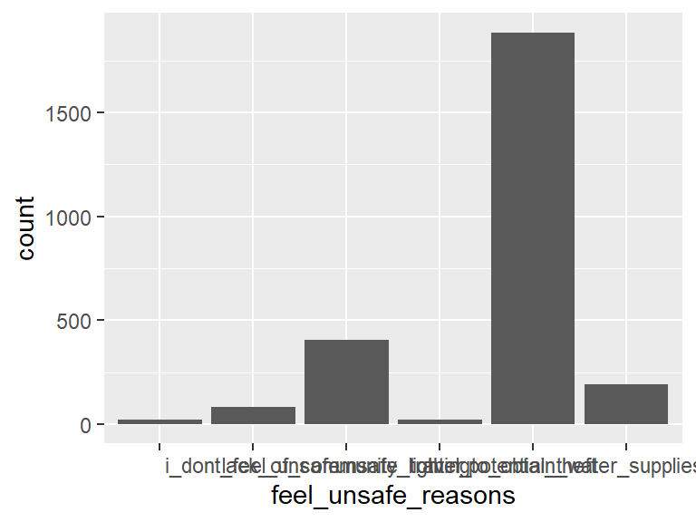

- The following suspected missing value codes enter as regular values: "".

## feel_safer_with_minigrid

| Feature | Result |
| --- | --- |
| Variable type | character |
| Number of missing obs. | 0 (0 %) |
| Number of unique values | 1284 |
| Mode | “yes” |

[figure not shown]

- The following suspected missing value codes enter as regular values: "".
- Note that the following levels have at most five observations: "*(bad_meter._\nmy_meter_is_bad_and_i_dont_have_light", "_old_days_we_having_problem_during_cloud_day_because_of_solar_energy", "24_hours_unlimited_light", "a_bit_safe._the_light_did_not_extend_to_streetlight", "a_bit_safe_but_the_community_still_needs_street_light", …, "yeswe_feel_good", "yeswe_feel_good_and_well", "you_fill_secur", "yss._having_light_in_my_holp_makes_me_feel_safe", "yy" (1244 values omitted).

## phone_charge_location

| Feature | Result |
| --- | --- |
| Variable type | character |
| Number of missing obs. | 0 (0 %) |
| Number of unique values | 5 |
| Mode | “home” |

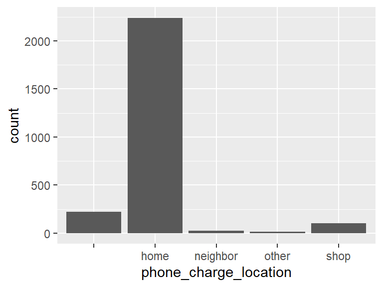

- The following suspected missing value codes enter as regular values: "".

## phone_charge_frequency

| Feature | Result |
| --- | --- |
| Variable type | character |
| Number of missing obs. | 0 (0 %) |
| Number of unique values | 5 |
| Mode | “every_day” |

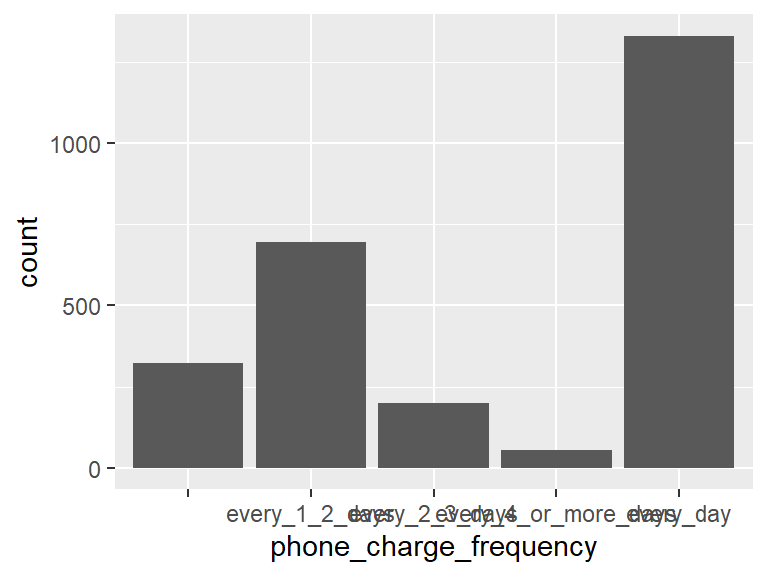

- The following suspected missing value codes enter as regular values: "".

## phone_charge_cost

| Feature | Result |
| --- | --- |
| Variable type | character |
| Number of missing obs. | 0 (0 %) |
| Number of unique values | 8 |
| Mode | “nothing_we_use_minigrid_power” |

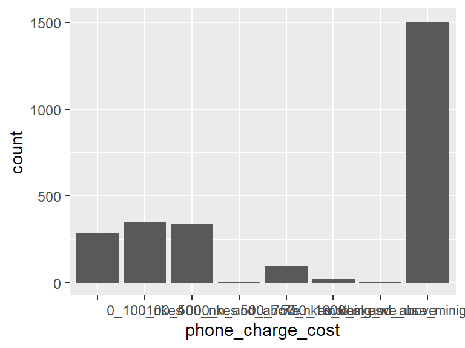

- The following suspected missing value codes enter as regular values: "".
- Note that the following levels have at most five observations: "1000_n_and_above".

## phone_charge_travel_distance

| Feature | Result |
| --- | --- |
| Variable type | character |
| Number of missing obs. | 0 (0 %) |
| Number of unique values | 9 |
| Mode | “no_need_to_travel__charge_at_home” |

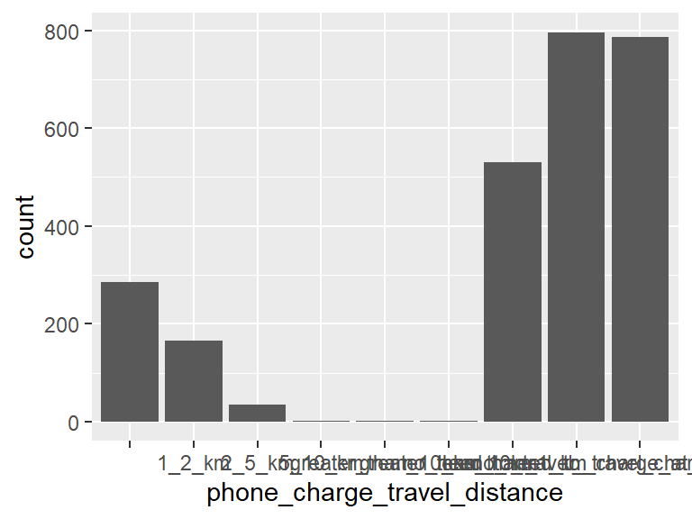

- The following suspected missing value codes enter as regular values: "".
- Note that the following levels have at most five observations: "5_10_km", "greater_than_10_km", "greater_than_10km".

## water_source

| Feature | Result |
| --- | --- |
| Variable type | character |
| Number of missing obs. | 0 (0 %) |
| Number of unique values | 6 |
| Mode | “community_well_or_pump” |

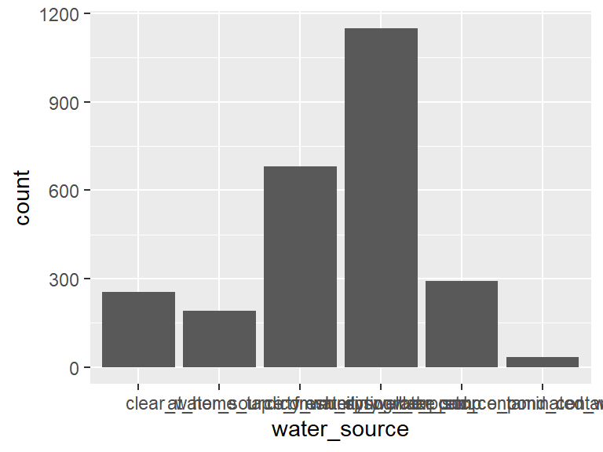

- The following suspected missing value codes enter as regular values: "".

## clean_drinking_water

| Feature | Result |
| --- | --- |
| Variable type | character |
| Number of missing obs. | 0 (0 %) |
| Number of unique values | 3 |
| Mode | “yes” |

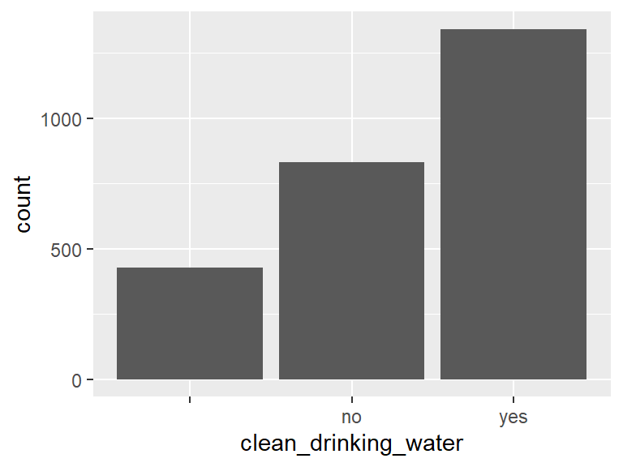

- The following suspected missing value codes enter as regular values: "".

## clean_drinking_water_source

| Feature | Result |
| --- | --- |
| Variable type | character |
| Number of missing obs. | 0 (0 %) |
| Number of unique values | 5 |
| Mode | “clean_community_source” |

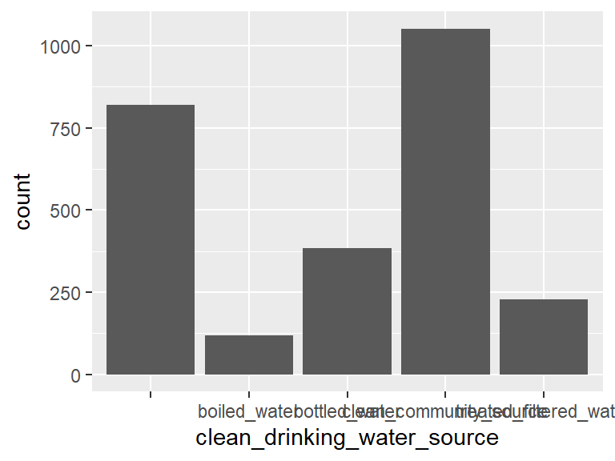

- The following suspected missing value codes enter as regular values: "".

## community_clean_water_source

| Feature | Result |
| --- | --- |
| Variable type | character |
| Number of missing obs. | 0 (0 %) |
| Number of unique values | 106 |
| Mode | “” |

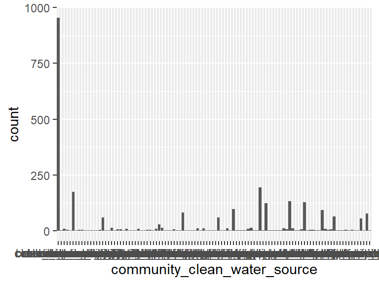

- The following suspected missing value codes enter as regular values: "".
- Note that the following levels have at most five observations: "bendeghe_afi", "bole_hole", "bolehole", "boreholecommunity_well", "clean_community_source", …, "water_for_community", "water_for_community_members", "water_for_the_entire_community", "water_pump_for_community", "well_and_stream" (61 values omitted).

## water_collection_travel_distance

| Feature | Result |
| --- | --- |
| Variable type | character |
| Number of missing obs. | 0 (0 %) |
| Number of unique values | 7 |
| Mode | “less_than_1_km” |

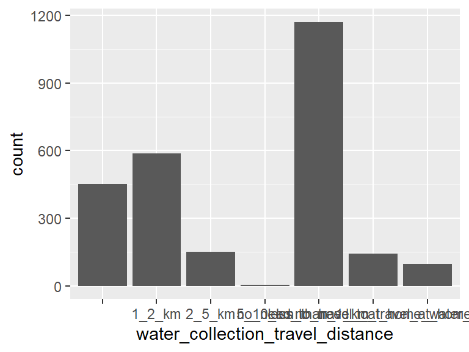

- The following suspected missing value codes enter as regular values: "".
- Note that the following levels have at most five observations: "5_10_km".

## water_collection_time

| Feature | Result |
| --- | --- |
| Variable type | character |
| Number of missing obs. | 0 (0 %) |
| Number of unique values | 6 |
| Mode | “less_than_1_hour” |

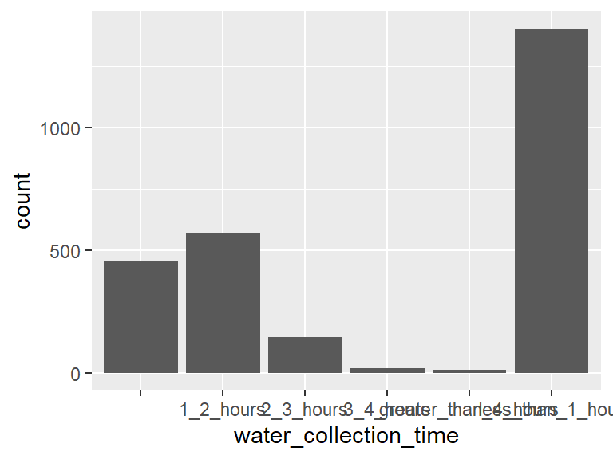

- The following suspected missing value codes enter as regular values: "".

## water_collection_responsible

| Feature | Result |
| --- | --- |
| Variable type | character |
| Number of missing obs. | 0 (0 %) |
| Number of unique values | 6 |
| Mode | “adult_female” |

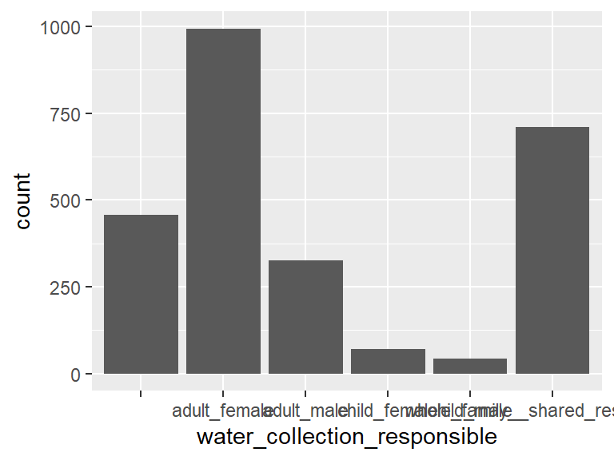

- The following suspected missing value codes enter as regular values: "".

## avg_person_age_water_collection

| Feature | Result |
| --- | --- |
| Variable type | character |
| Number of missing obs. | 0 (0 %) |
| Number of unique values | 7 |
| Mode | “15_18_old” |

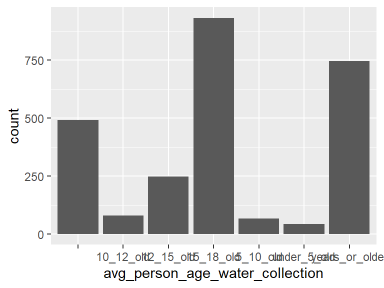

- The following suspected missing value codes enter as regular values: "".

## water_cost

| Feature | Result |
| --- | --- |
| Variable type | character |
| Number of missing obs. | 0 (0 %) |
| Number of unique values | 7 |
| Mode | “i_dont_pay_its_free” |

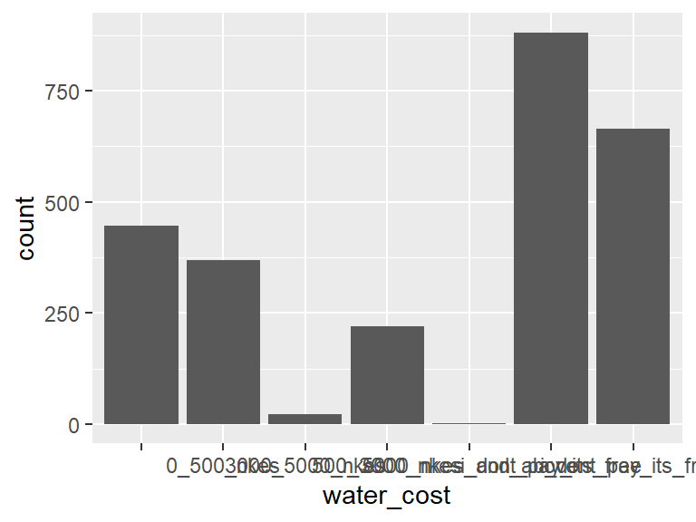

- The following suspected missing value codes enter as regular values: "".
- Note that the following levels have at most five observations: "5000_nkes_and_above".

## clinic_travel_distance

| Feature | Result |
| --- | --- |
| Variable type | character |
| Number of missing obs. | 0 (0 %) |
| Number of unique values | 7 |
| Mode | “less_than_1_km” |

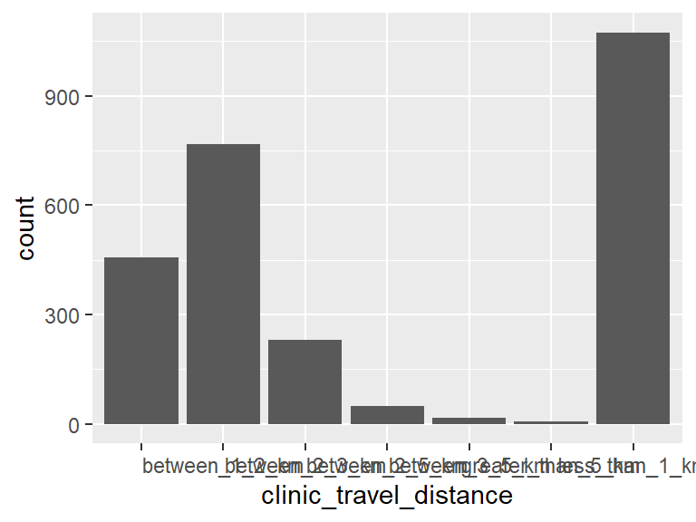

- The following suspected missing value codes enter as regular values: "".

## clinic_electricity_access_minigrid

| Feature | Result |
| --- | --- |
| Variable type | character |
| Number of missing obs. | 0 (0 %) |
| Number of unique values | 3 |
| Mode | “yes” |

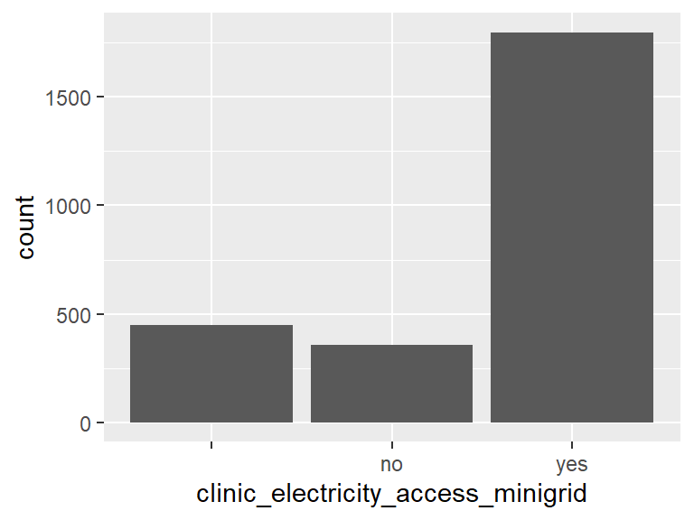

- The following suspected missing value codes enter as regular values: "".

## clinic_refrigeration_access

| Feature | Result |
| --- | --- |
| Variable type | character |
| Number of missing obs. | 0 (0 %) |
| Number of unique values | 3 |
| Mode | “yes” |

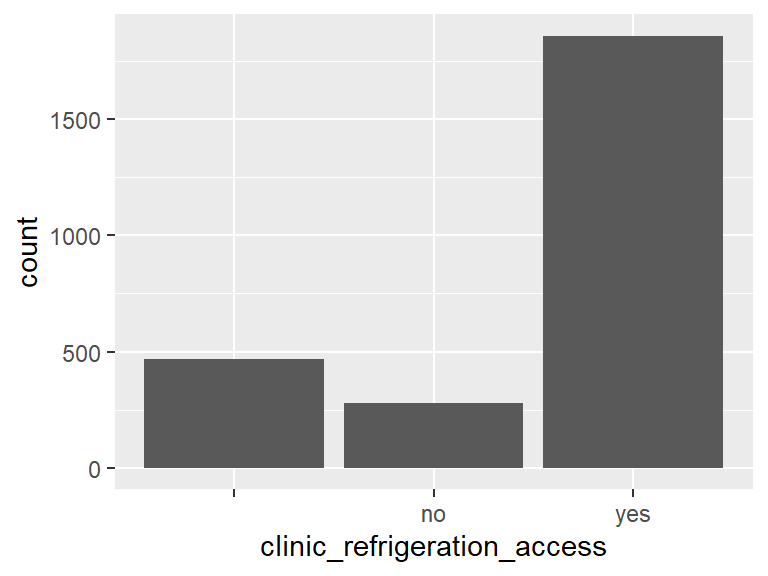

- The following suspected missing value codes enter as regular values: "".

## better_access_health_minigrid

| Feature | Result |
| --- | --- |
| Variable type | character |
| Number of missing obs. | 0 (0 %) |
| Number of unique values | 3 |
| Mode | “yes” |

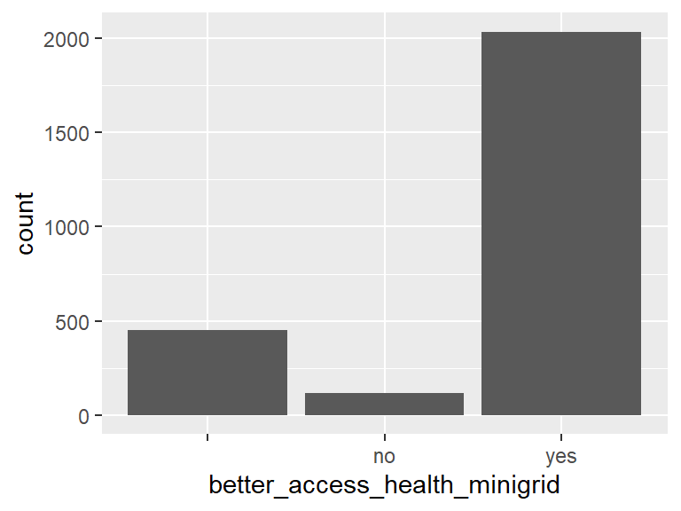

- The following suspected missing value codes enter as regular values: "".